# SAA 2017 Workshop: Using R for Archaeological Data Analysis, Mapping, and Visualization

Local spatial autocorrelation statistics: A reproduced research case

Domenico Giusti

## Introduction

Standing on this principle, the present project aims to experiment with local spatial autocorrelation statistics, reproducing the results of an original research by L.S.Premo (2004) “Local spatial autocorrelation statistics quantify multi-scale patterns in distributional data: an example from the Maya Lowlands”, Journal of Archaeological Science 31, 855-866.

Autocorrelation is a measure of similarity (correlation) between nearby observations. Measures of spatial autocorrelation describe the degree two which observations (values) at spatial locations are similar to each other (http://rspatial.org). Unlike their global counterpart, the local indicators of spatial association (LISA) (Anselin 1995) do not assume an homogeneous distribution, but investigate correlations at the local level.

Despite the great potential of LISA in the analysis of archaeological spatial patterning, local spatial autocorrelation statistics have found very few archaeological applications (Premo 2004; Cardillo, Borrazzo, and Charlin 2016).

Premo’s research serves as

> one example of how local spatial statistics can further strengthen distributional archaeological interpretation. (Premo 2004)

By applying local Moran’s I<sub>i</sub> and G<sub>i</sub> statistics to a set of 47 dated Classical Period monuments in the southern Maya Lowlands, Premo (2004) quantitatively detects at local scale previously unobserved spatial structures.

## Reading data

> Site coordinates have been included in this report in hopes that interested researchers will take this opportunity to experiment with the local spatial autocorrelation analysis. (Premo 2004, 858)

```
## [1] "/home/dncgst/project/premo2004_rr/src"
```

> Table 1 presents the spatial data used in this analysis. Note that it includes the same 47 sites that Bove (1981), Whitley and Clark (1985), Kvamme (1990), and Williams (1993) analyzed. (Premo 2004, 858)

| Site.number | Site.name | Northing..km. | Easting..km. | Monument | Long.count.date | Date..AD. |
| --- | --- | --- | --- | --- | --- | --- |
| 1 | Aguas Calientes | 194 | 239 | Stela 1 | 9.18.0.13.18 | 791 |
| 2 | Aguateca | 171 | 252 | New Stela | 9.18.3.0.17 | 793 |
| 3 | Altar de Sacrificios | 184 | 218 | Stela 15 | 9.17.0.0.0 | 771 |
| 4 | Benque Viejo | 248 | 371 | Stela 1 | 10.1.0.0.0 | 849 |
| 5 | Bonampak | 210 | 158 | Murals | 9.17.15.12.10 | 792 |
| 6 | Calakmul | 355 | 294 | Stela 64 | 9.19.0.0.0 | 810 |
| 7 | Cancuen | 132 | 268 | Stela 1 | 9.18.10.0.0 | 800 |
| 8 | Caracol | 208 | 369 | Stela 17 | 10.1.0.0.0 | 849 |
| 9 | Chinkultic | 145 | 87 | Stela 1 | 10.0.15.0.0 | 844 |
| 10 | Comitan | 156 | 45 | Stela 1 | 10.2.5.0.0 | 874 |
| 11 | Copan | 6 | 371 | Altar L | 9.19.11.14.5 | 822 |
| 12 | El Caribe | 190 | 232 | Stela 2 | 9.17.10.0.0 | 780 |
| 13 | El Cayo | 248 | 142 | New | 9.18.1.12.16 | 792 |
| 14 | El Palmar | 358 | 348 | Stela 41 | 10.2.15.0.0 | 884 |
| 15 | Ixkun | 190 | 335 | Stela 5 | 9.18.10.0.0 | 800 |
| 16 | Ixlu | 229 | 313 | Stela 2 | 10.2.10.0.0 | 879 |
| 17 | La Amelia | 184 | 232 | Panel 1 | 9.18.17.1.13 | 807 |
| 18 | La Florida | 23 | 395 | Stela 7 | 9.16.15.0.0 | 766 |
| 19 | La Honradez | 297 | 355 | Stela 4 | 9.18.0.0.0 | 790 |
| 20 | La Mar | 248 | 129 | Stela 2 | 9.18.15.0.0 | 805 |
| 21 | La Milpa | 326 | 381 | Stela 7 | 9.17.10.0.0 | 780 |
| 22 | La Muneca | 369 | 329 | Stela 1 | 10.3.0.0.0 | 889 |
| 23 | Lubaantun | 156 | 387 | Altar 2 | 9.18.0.0.0 | 790 |
| 24 | Machaquila | 168 | 294 | Stela 5 | 10.0.10.17.5 | 841 |
| 25 | Morales | 335 | 119 | Stela 1 | 9.16.5.0.0 | 756 |
| 26 | Naachtun | 326 | 303 | Stela 10 | 10.16.10.0.0 | 761 |
| 27 | Nakum | 258 | 339 | Stela D | 10.1.0.0.0 | 849 |
| 28 | Naranjo | 252 | 355 | Stela 32 | 9.19.10.0.0 | 820 |
| 29 | Oxpemul | 381 | 300 | Stela 7 | 10.0.0.0.0 | 830 |
| 30 | Palenque | 295 | 65 | Tablet 96 | 9.17.13.0.7 | 783 |
| 31 | Piedras Negras | 258 | 142 | Altar 3 | 9.19.0.0.0 | 810 |
| 32 | Polol | 216 | 252 | Stela 1 | 9.18.0.0.0 | 790 |
| 33 | Pusilha | 135 | 368 | Stela E | 9.15.0.0.0 | 731 |
| 34 | Quen Santo | 132 | 90 | Stela 2 | 10.2.10.0.0 | 879 |
| 35 | Quirigua | 45 | 374 | Temple 1 | 9.19.0.0.0 | 810 |
| 36 | Seibal | 182 | 271 | Stelae 18, 20 | 10.3.0.0.0 | 889 |
| 37 | Tayasal-Flores | 232 | 287 | Stela 1 | 10.2.0.0.0 | 869 |
| 38 | Tikal | 261 | 313 | Stela 11 | 10.2.0.0.0 | 869 |
| 39 | Tila | 226 | 8 | Stela A | 10.0.0.0.0 | 830 |
| 40 | Tonina | 232 | 60 | Monument 101 | 10.4.0.0.0 | 909 |
| 41 | Tzmin Kax | 213 | 377 | Altar 1 | 10.0.5.0.0 | 835 |
| 42 | Uaxactun | 281 | 315 | Stela 12 | 10.3.0.0.0 | 889 |
| 43 | Ucanal | 223 | 334 | Stela 4 | 10.1.0.0.0 | 849 |
| 44 | Uxul | 332 | 277 |  | 9.16.0.0.0 | 751 |
| 45 | Xultun | 290 | 339 | Stela 10 | 10.3.0.0.0 | 889 |
| 46 | Yaxchilan | 226 | 171 | Lintel 10 | 9.18.17.13.14 | 808 |
| 47 | Yaxha | 248 | 335 | Stela 31 | 9.18.5.16.4 | 796 |

## Data analysis: Local spatial autocorrelation statistics

### Spatial neighbours

> The first step is to define which relationships between observations are to be given a non-zero weight, that is to choose the neighbour criterion to be used (Bivand, Pebesma, and Rubio 2008, 239)

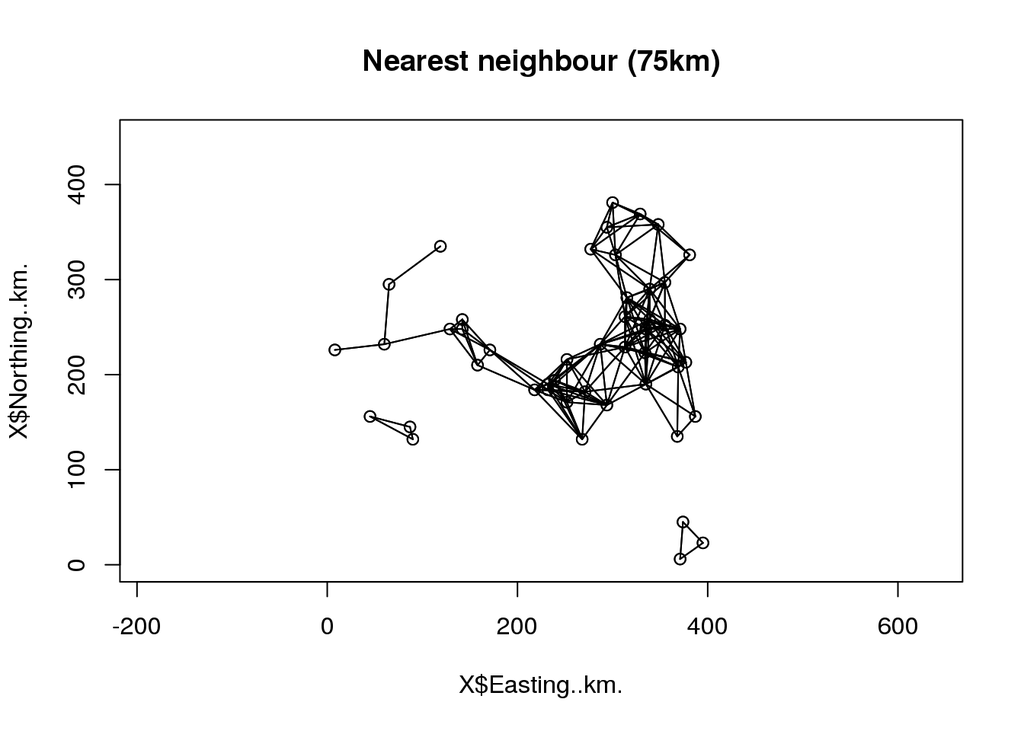

```r
# graph-based neighbours
# > All the graph-based neigbour schemes always ensure that all the points will have at least one neighbour. [@Bivand2008, p.246]
# > Note that graph-based representations contruct the interpoint relationships based on Euclidean distance, with no option to use Great Circle distances for geographical coordinates. [@Bivand2008, p.244]
## Delaunay triangulation neighbours
# > The neighbour relationships are defined by the triangulation, which extends outwards to the convex hull of the points.
## Sphere of Influence neighbours
# > SOI thins the triangulation, removing links that are relatively long. Delaunay and SOI neighbours are symmetric by design: if i is a neighbour of j, then j is a neighbour of i.
## Gabriel graph neighbours
# > Gabeial graph is also a subgraph of the Delaunay triangulation, retaining a different set of neigbours. It does not, however, guarantee symmetry.
## Relative graph neighbours

# distance-based neighbours
# > An alternative method is to choose the k nearest neighbours - this adapts across the study area, taking account of differences in the densities of areal entities. Naturally, in the overwhelming majority of cases, it leads to asymmetric neighbours, but will ensure that all areas have k neighbours. [...] knearneigh can also take a longlat argument to handle geographical coordinates. [@Bivand2008, p.246]
## k nearest neighbour
## nearest neighbour based on a specified distance
# > The k=1 object is also useful in finding the minimum distance at which all areas have a distance-based neighbour. [@Bivand2008, p.246]
## nearest neighbour by row distance
X_nb75 <- dnearneigh(coords, d1=0, d2=75, row.names=id)
plot(X$Easting..km., X$Northing..km., xlim=c(0,450), ylim=c(0,450), asp=1, main="Nearest neighbour (75km)")
plot(X_nb75, coords, add=TRUE)
```

```r
# higher-order neighbours
# > Distance bands can be generated by using a sequence of d1 and d2 argument values for the dnearneigh function if needed to construct a spatial autocorrelogram as understood in ecology. In other conventions, correlograms are constructed by taking an input list of neighbours as the first-order sets, and stepping out across the graph to [...] higher-order neighbours [@Bivand2008, p.249]
```